# NMF Clustering on combined data

Camilo Posso

11/30/2021

# Non-negative matrix factorization

NMF has been successfully used to cluster patients using combined proteomics, phosphoproteomics, and RNA count datasets. In these applications, the clusters of samples were found to coincide with previous biological knowledge, suggesting that NMF could be useful in extracting biological relationships among patients. As is common, in addition to the dataset, NMF also requires input on `how many` clusters to divide the samples into, denoted by $k$.

It is a stochastic method which factors a non-negative matrix $M$ into two non-negative matrices $M = WH$. The rows of $W$ correspond to rows (or genes) of $M$, while the columns of $H$ are the columns, or samples of $M$. The matrix $H$, being non-negative, provides a natural way to assign a cluster to every sample, as the largest entry in $H$ in that column. Given that the NMF method is stochastic, the `stability` of the clusters provides a method of settling on a single optimal $k$ value.

The cophenetic correlation is a common way to measure this stability. Often, the value of $k$ giving the largest cophenetic correlation is chosen. The precise clusters are obtained by averaging the results of many runs. Below, we see the cophenetic correlation for each $k$ between 2 and 8, using a total of 50 runs for each $k$ value.

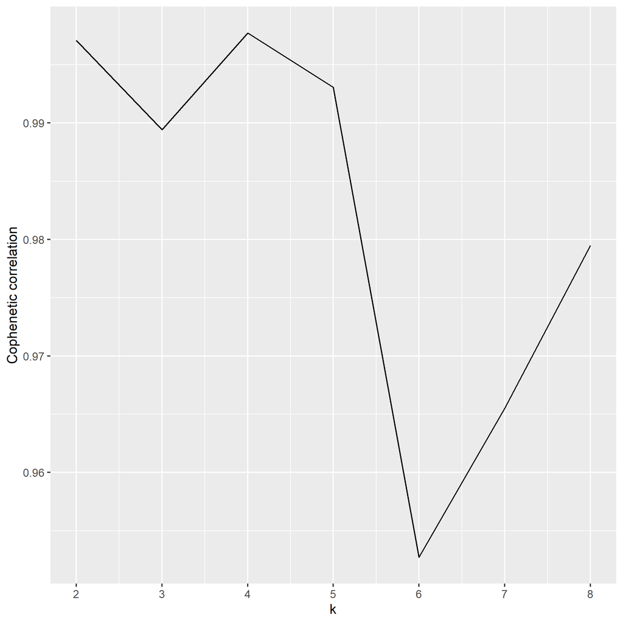

```r
knitr::include_graphics("Data/cophenetic_correlation.png")
```

$$\\[0.1in]$$

As the cophenetic correlation is quite close between these, I selected 4 in particular which have high cophenetic correlation and/or agreement the FLT3 or Chemotherapy status.

We summarize the results of for each $k$ value below. Each one is the result of averaging 50 individual NMF clusters, and is represented as a heatmap.  
Both the rows and columns are samples. For a pair of samples $(S_1, S_2)$, the value seen plotted is the proportion of times the two samples are assigned to the same cluster by the algorithm. They can also be interpreted as the probability that the samples belong to the same cluster. Red blocks correspond to the various clusters, while a darker color (red or blue) indicates more consensus among the clustering results.

We also annotate the FLT3, Chemotherapy, RAS, and NPM1 status of the patients, to see if these coincide with the clusters. On the rows, we color the samples according to the enrichment of FLT3, Chemotherapy, RAS and NPM1 in that cluster. Note we use a negative logarithmic scale, with $2 = -log_{10}(0.01)$ indicating a p-value of 0.01.

### $k = 2$

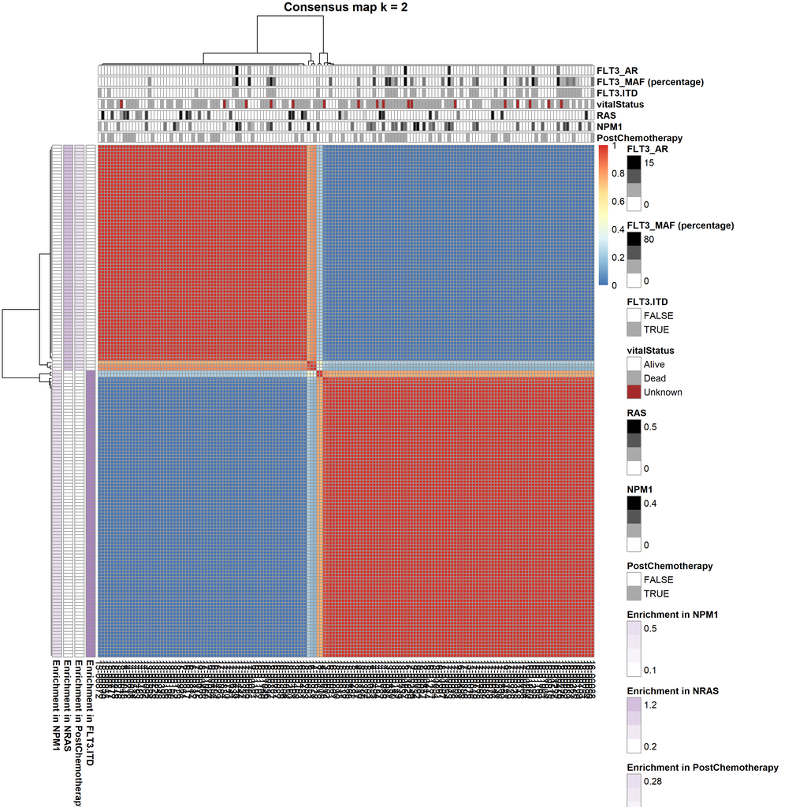

```r
knitr::include_graphics("Data/consensus_map_k_2.png")
```

$$\\[0.1in]$$

### $k = 4$

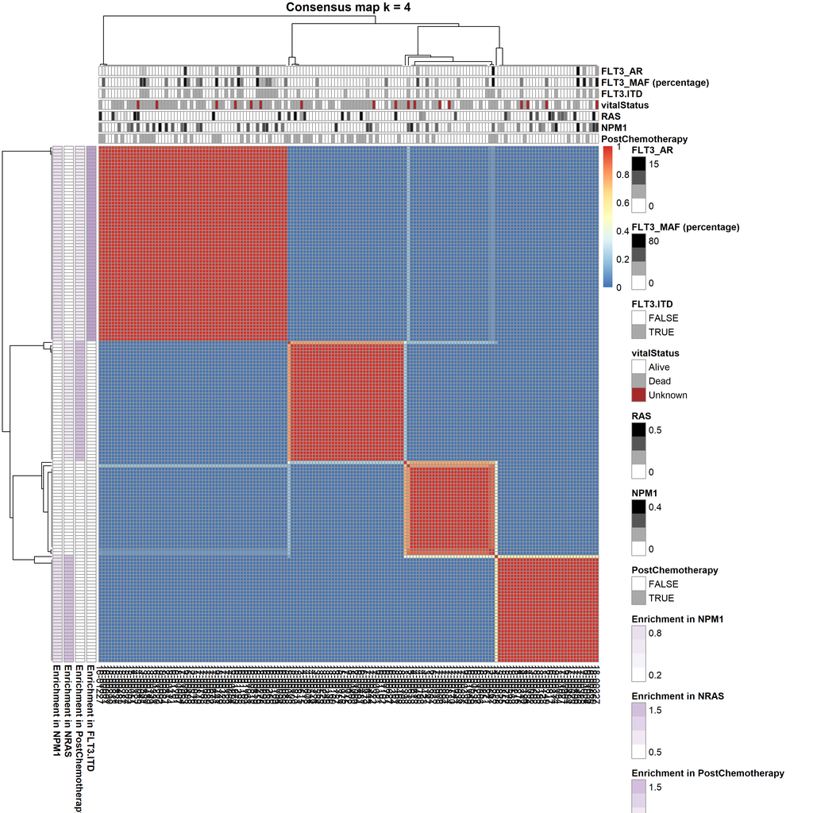

```r
knitr::include_graphics("Data/consensus_map_k_4.png")
```

$$\\[0.1in]$$

### $k = 5$

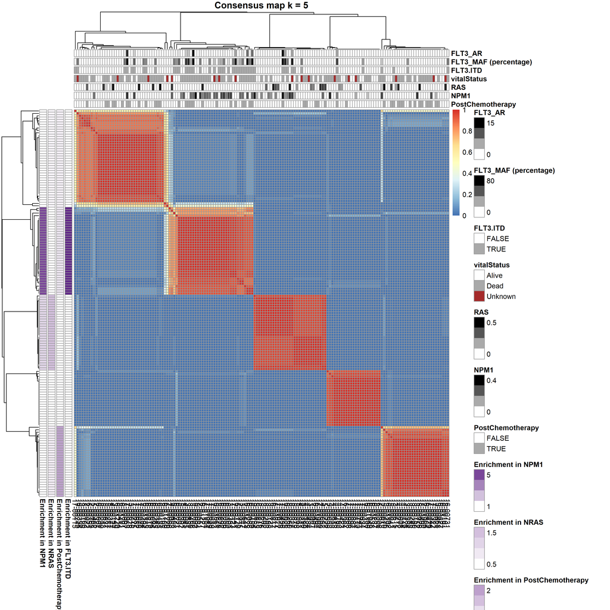

```r
knitr::include_graphics("Data/consensus_map_k_5.png")
```

$$\\[0.1in]$$

### $k = 8$

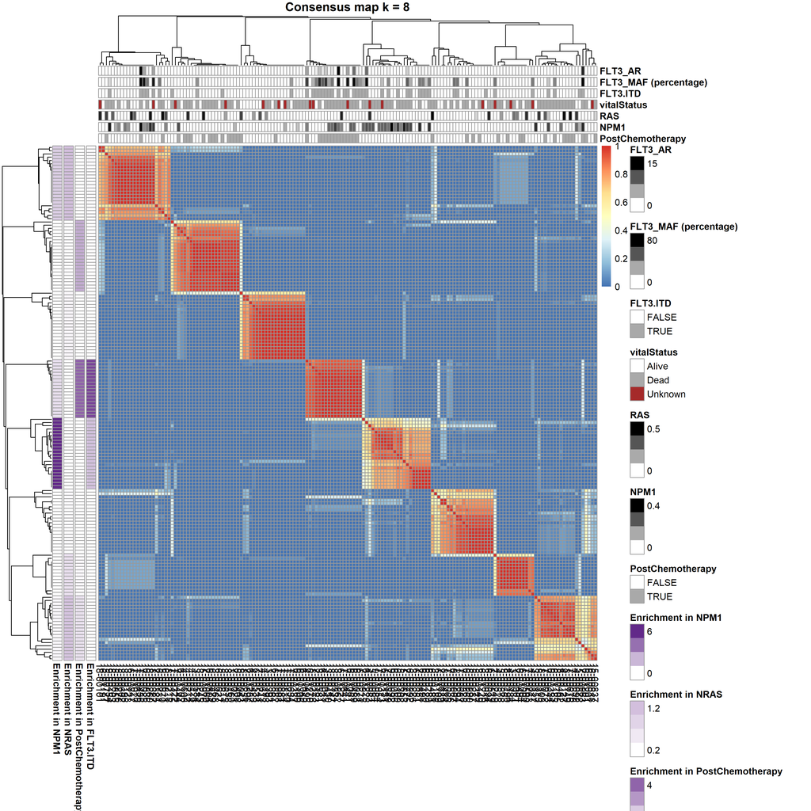

```r
knitr::include_graphics("Data/consensus_map_k_8.png")
```

```r
## Writing table with clusters to share
## Contains cluster membership and meta data.

# sample.cats <- ann.labels %>%
#   mutate(Barcode.ID = rownames(.))
#
# share <- get.clusters(results) %>%
#   mutate(Barcode.ID = rownames(.)) %>%
#   left_join(sample.cats, by = "Barcode.ID") %>%
#   column_to_rownames("Barcode.ID") %>%
#   write.table(file = "Data/Sample cluster membership and metadata.txt",
#               sep = "\t", quote = F)
```